# Outline

# Time series

```python
import pandas as pd
df = pd.read_csv('FAO.csv')
```

```python
print(df.info())
```

```python
df.set_index('Year', inplace = True)
```

```python
print(df.info())
```

```python
df.head()
```

https://pandas.pydata.org/pandas-docs/stable/user_guide/timeseries.html

```python
pd.to_datetime(df.index, format='%Y')
```

```python
pd.to_datetime(df.index, format='%Y').to_period('Y')
```

```python
# you need to rerun the previous if rerun this line
df.index = pd.to_datetime(df.index, format='%Y').to_period('Y')
df.head()
```

```python
print(df.info())
```

# Discussion 5: Time series

Study the read_csv() function (http://pandas.pydata.org/pandas-docs/stable/generated/pandas.read_csv.html).

[figure not shown]

## Set index first

```python
import pandas as pd2
df2 = pd2.read_csv('GOOGL.csv', index_col='Date',parse_dates=True)
```

```python
df2.head()
```

```python
df2.info()
```

## Set index later

```python
import pandas as pd1
df1 = pd1.read_csv('GOOGL.csv', parse_dates=False)
```

```python
df1.info()
```

```python
df1.set_index('Date', inplace = True)
```

```python
df1.info()
```

```python
pd1.to_datetime(df1.index, format='%Y-%M-%d')
```

```python
pd1.to_datetime(df1.index, format='%Y-%M-%d').to_period('D')
```

```python
df1.index =pd1.to_datetime(df1.index, format='%Y-%M-%d').to_period('D')
```

```python
df1.info()
```

# Discussion 6: DatetimeIndex slicing

Study the examples at http://pandas.pydata.org/pandas-docs/stable/timeseries.html#partial-string-indexing

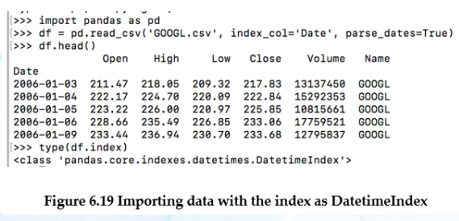

Refer to Figure 6.19. Write code to slice

- rows from 2006-01-05 to 2006-01-09
- all rows in the month 2006-01

```python
import pandas as pd
df = pd.read_csv('GOOGL.csv', index_col='Date',parse_dates=True)
df.head()
```

```python
df['2006-01-05':'2006-01-09']
```

```python
df['2006-01']
```

# Discussion 7: Bar plot

Study the examples at http://pandas.pydata.org/pandas-docs/stable/generated/pandas.DataFrame.plot.bar.html

Write code to draw a bar plot for the top 10 production areas, from the output below.

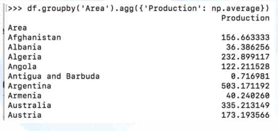

```python
import pandas as pd
import numpy as np
df = pd.read_csv('FAO.csv')
data = df.groupby('Area').agg({'Production': np.average})
```

```python
data
```

```python
data.sort_values(by='Production', ascending=False)
```

```python
data.sort_values(by='Production', ascending=False)[0:10]
```

```python
plotData = data.sort_values(by='Production', ascending=False)[0:10]
```

```python
plotData.info()
```

```python
plotData.plot.bar()
```

# Discussion 8: Box plot

https://pandas.pydata.org/pandas-docs/stable/reference/api/pandas.DataFrame.boxplot.html

## Example 1

```python
np.random.seed(1234)
df = pd.DataFrame(np.random.randn(10,4),
                  columns=['Col1', 'Col2', 'Col3', 'Col4'])
df
```

```python
df.boxplot(column=['Col1', 'Col2', 'Col3'])
```

## Example 2

```python
df = pd.DataFrame(np.random.randn(10, 2),columns=['Col1', 'Col2'])
df
```

```python
df['X'] = pd.Series(['A', 'A', 'A', 'A', 'A','B', 'B', 'B', 'B', 'B'])
df
```

```python
df.dtypes
```

```python
df['X']
```

```python
type(df['X'])
```

```python
df.boxplot(by='X')
```

## Question

Study the examples at http://pandas.pydata.org/pandas-docs/stable/generated/pandas.DataFrame.boxplot.html

[figure not shown]

```python
import pandas as pd
#import numpy as np
df = pd.read_csv('FAO.csv')
df.head()
```

```python
df.set_index('Item',inplace=True)
```

```python
df.info()
```

```python
data = df.loc['Coffee and products',['Area','Production']]
data
```

```python
data.set_index('Area',inplace=True)
```

```python
data
```

```python
data=data.loc[['France', 'Germany']]
```

```python
data
```

```python
data =data.reset_index()
```

```python
data
```

```python
data.boxplot(by='Area')
```

# Discussion 9:Histogram

Study the examples at http://pandas.pydata.org/pandas-docs/stable/generated/pandas.DataFrame.hist.html

[figure not shown]

```python
data.hist(by='Area')
```